# R语言与机器学习（下）

小天使格礼

在Rstudio中安装本节课所有需要的包，运行以下指令：

```r
install.packages(c(
  "dplyr", "tidyr", "data.table",
  "ggplot2", "patchwork", "RColorBrewer", "factoextra",
  "cluster", "mclust", "dbscan", "Rtsne", "umap",
  "arules", "arulesViz", "arulesSequences",
  "caret", "randomForest", "xgboost", "iml", "DALEX", "pdp", "lime",
  "forecast", "prophet", "fpp2",
  "tm", "SnowballC", "wordcloud", "topicmodels", "tidytext", "jiebaR",
  "recommenderlab",
  "isotree", "dbscan",
  "purrr", "broom", "knitr", "mlbench"
))
```

# 目录

| 章节 | 主题 | 核心内容 |
| --- | --- | --- |
| 第九章 | 无监督学习 | 聚类方法、降维、异常检测 |
| 第十章 | 关联规则与模式挖掘 | Apriori、FP-Growth、频繁项集 |
| 第十一章 | 特征选择与降维 | 过滤法、包装法、嵌入法 |
| 第十二章 | 模型解释与可解释性 | SHAP、LIME、PDP、公平性 |
| 第十三章 | 时间序列机器学习 | 特征工程、Prophet、交叉验证 |
| 第十四章 | 文本挖掘基础 | TF-IDF、主题模型、文本分类 |
| 第十五章 | 推荐系统基础 | 协同过滤、矩阵分解、评估指标 |

# 第九章 无监督学习

## 9.1 聚类方法概述

### 什么是聚类？

**聚类（Clustering）** 是一种无监督学习方法，目标是将相似的样本归为同一组（簇），使组内样本相似度高、组间样本相似度低。

**与分类的区别**：

| 对比维度 | 分类 | 聚类 |
| --- | --- | --- |
| 学习类型 | 监督学习 | 无监督学习 |
| 标签 | 有标签 | 无标签 |
| 目标 | 预测已知类别 | 发现数据结构 |
| 评估 | 准确率等 | 轮廓系数等 |

### 聚类方法分类

| 方法类型 | 代表算法 | 核心思想 | 适用场景 |
| --- | --- | --- | --- |
| 划分方法 | K-Means | 最小化簇内距离 | 球形簇、规模适中 |
| 层次方法 | 凝聚式聚类 | 自底向上合并 | 层次结构、小数据 |
| 密度方法 | DBSCAN | 密度相连区域 | 任意形状、有噪声 |
| 模型方法 | GMM | 概率分布拟合 | 概率聚类、软分配 |
| 图方法 | 谱聚类 | 图分割 | 非凸形状、复杂结构 |

### 意义与使用场景

**核心意义**：聚类帮助发现数据的内在结构，是数据探索和模式发现的基础工具。

**举例**：患者分型研究

**为什么这种数据适合用聚类？**

在医学研究中，往往存在多种疾病亚型，但临床诊断标准可能无法完全区分。例如，糖尿病患者可能有不同的代谢特征组合，传统分类方法可能遗漏某些亚型。聚类分析可以基于患者的多项指标（血糖、胰岛素、BMI、血脂等）自动发现潜在的患者亚群。

**研究目的是什么？**

1. 发现疾病亚型：识别具有相似特征的患者群体
2. 精准医疗：为不同亚型制定个性化治疗方案
3. 风险分层：识别高风险或特殊预后的患者群体

**可能得到什么样的结果？**

聚类可能发现3-4个患者亚群：代谢正常型、肥胖相关型、自身免疫型等。每个亚群可能有不同的治疗响应和预后。

**需要注意什么？**

聚类结果需要结合临床知识进行解释和验证。不同的聚类方法和参数可能得到不同的结果，需要进行稳定性分析。

## 9.2 K-Means聚类

### 基本原理

**K-Means** 是最常用的聚类算法，通过迭代优化将数据划分为K个簇：

**算法步骤**： 1. 随机初始化K个聚类中心 2. 将每个样本分配到最近的聚类中心 3. 重新计算每个簇的中心（均值） 4. 重复步骤2-3直到收敛

**目标函数**：

$$J = \sum_{k=1}^{K} \sum_{x_i \in C_k}
\|x_i - \mu_k\|^2$$

其中$\mu_k$是簇$C_k$的中心。

```r
# K-Means聚类示例
set.seed(42)

# 生成模拟数据：三个患者群体
n_per_group <- 50

# 创建三种不同特征的患者群体
patient_data <- data.frame(
  # 特征1：炎症指标
  inflammation = c(
    rnorm(n_per_group, mean = 5, sd = 1),    # 低炎症组
    rnorm(n_per_group, mean = 10, sd = 1.5), # 中炎症组
    rnorm(n_per_group, mean = 15, sd = 2)    # 高炎症组
  ),
  # 特征2：代谢指标
  metabolism = c(
    rnorm(n_per_group, mean = 3, sd = 0.8),
    rnorm(n_per_group, mean = 6, sd = 1),
    rnorm(n_per_group, mean = 9, sd = 1.2)
  ),
  # 真实标签（仅用于验证，聚类时不用）
  true_group = rep(c("低风险", "中风险", "高风险"), each = n_per_group)
)

# 执行K-Means聚类（假设不知道真实分组）
kmeans_result <- kmeans(patient_data[, c("inflammation", "metabolism")],
                        centers = 3, nstart = 25)

# 将聚类结果添加到数据框
patient_data$cluster <- as.factor(kmeans_result$cluster)

# 查看聚类中心
print("聚类中心：")
```

```
## [1] "聚类中心："
```

```r
print(kmeans_result$centers)
```

```
##   inflammation metabolism
## 1    14.936596   9.109263
## 2     4.975035   3.027561
## 3    10.374221   6.118794
```

```r
# 查看簇大小
print("各簇样本数：")
```

```
## [1] "各簇样本数："
```

```r
print(kmeans_result$size)
```

```
## [1] 46 51 53
```

### 可视化聚类结果

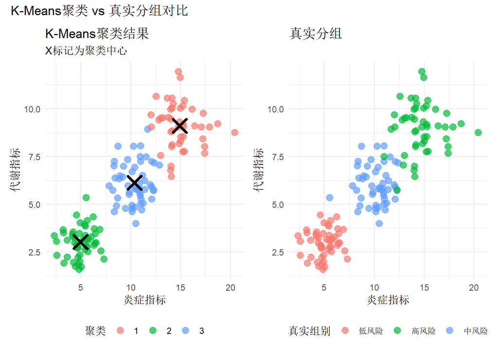

```r
# 可视化聚类结果
p1 <- ggplot2::ggplot(patient_data, ggplot2::aes(x = inflammation, y = metabolism)) +
  ggplot2::geom_point(ggplot2::aes(color = cluster), size = 3, alpha = 0.7) +
  ggplot2::geom_point(data = as.data.frame(kmeans_result$centers),
                      ggplot2::aes(x = inflammation, y = metabolism),
                      shape = 4, size = 5, stroke = 2, color = "black") +
  ggplot2::labs(
    title = "K-Means聚类结果",
    subtitle = "X标记为聚类中心",
    x = "炎症指标", y = "代谢指标", color = "聚类"
  ) +
  ggplot2::theme_minimal() +
  ggplot2::theme(legend.position = "bottom")

# 对比真实分组
p2 <- ggplot2::ggplot(patient_data, ggplot2::aes(x = inflammation, y = metabolism)) +
  ggplot2::geom_point(ggplot2::aes(color = true_group), size = 3, alpha = 0.7) +
  ggplot2::labs(
    title = "真实分组",
    x = "炎症指标", y = "代谢指标", color = "真实组别"
  ) +
  ggplot2::theme_minimal() +
  ggplot2::theme(legend.position = "bottom")

p1 + p2 + patchwork::plot_annotation(
  title = "K-Means聚类 vs 真实分组对比"
)
```

### 肘部法则选择K值

**肘部法则（Elbow Method）**：绘制不同K值对应的簇内平方和（WSS），选择拐点作为最佳K值。

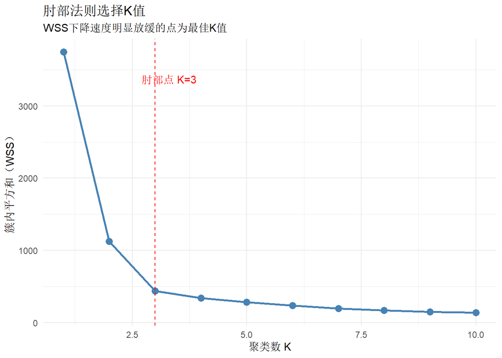

```r
# 肘部法则：计算不同K值的WSS
wss_values <- sapply(1:10, function(k) {
  kmeans(patient_data[, c("inflammation", "metabolism")],
         centers = k, nstart = 25)$tot.withinss
})

# 创建数据框用于可视化
elbow_df <- data.frame(
  k = 1:10,
  wss = wss_values
)

# 绘制肘部图
ggplot2::ggplot(elbow_df, ggplot2::aes(x = k, y = wss)) +
  ggplot2::geom_line(color = "steelblue", linewidth = 1) +
  ggplot2::geom_point(color = "steelblue", size = 3) +
  ggplot2::geom_vline(xintercept = 3, linetype = "dashed", color = "red") +
  ggplot2::annotate("text", x = 3.3, y = max(wss_values) * 0.9,
                    label = "肘部点 K=3", color = "red") +
  ggplot2::labs(
    title = "肘部法则选择K值",
    subtitle = "WSS下降速度明显放缓的点为最佳K值",
    x = "聚类数 K", y = "簇内平方和（WSS）"
  ) +
  ggplot2::theme_minimal()
```

### 轮廓系数评估聚类质量

**轮廓系数（Silhouette Coefficient）** 衡量样本与同簇样本的相似度 vs 与其他簇样本的相似度：

$$s(i) = \frac{b(i) - a(i)}{\max(a(i),
b(i))}$$

其中： - $a(i)$：样本$i$与同簇其他样本的平均距离 - $b(i)$：样本$i$与最近其他簇样本的平均距离

**取值范围**：$-1 \leq s(i) \leq 1$，越接近1表示聚类效果越好。

```
##   cluster size ave.sil.width
## 1       1   46          0.53
## 2       2   51          0.72
## 3       3   53          0.56
```

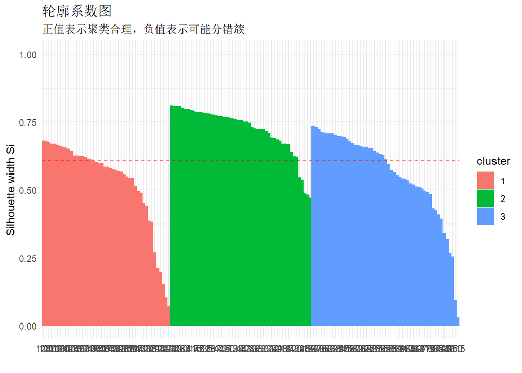

```r
# 计算轮廓系数
silhouette_result <- cluster::silhouette(
  kmeans_result$cluster,
  dist(patient_data[, c("inflammation", "metabolism")])
)

# 使用factoextra包可视化轮廓系数
factoextra::fviz_silhouette(silhouette_result) +
  ggplot2::labs(
    title = "轮廓系数图",
    subtitle = "正值表示聚类合理，负值表示可能分错簇"
  ) +
  ggplot2::theme_minimal()
```

```r
# 计算平均轮廓系数
avg_silhouette <- mean(silhouette_result[, 3])
print(paste("平均轮廓系数:", round(avg_silhouette, 3)))
```

```
## [1] "平均轮廓系数: 0.606"
```

### 初始化方法

K-Means对初始中心敏感，常用改进方法：

| 方法 | 说明 | R实现 |
| --- | --- | --- |
| 随机初始化 | 随机选择K个样本作为初始中心 | `kmeans()`默认 |
| K-Means++ | 选择距离已选中心较远的点 | `kmeans(nstart > 1)` |
| 多次运行 | 运行多次选择最优结果 | `nstart`参数 |

```r
# 使用nstart参数多次运行，选择最优结果
kmeans_multi <- kmeans(patient_data[, c("inflammation", "metabolism")],
                       centers = 3, nstart = 50)

print(paste("最优结果的WSS:", round(kmeans_multi$tot.withinss, 2)))
```

```
## [1] "最优结果的WSS: 434.39"
```

### 意义与使用场景

**核心意义**：K-Means是最常用的聚类方法，简单高效，适合大规模数据的初步探索。

**举例**：医院患者分型

**为什么这种数据适合用K-Means？**

医院积累了大量患者的检验指标数据，如血常规、生化指标等。这些数据通常是连续型数值，且患者群体可能存在自然的分组（如不同疾病类型、不同严重程度）。K-Means可以快速发现这些潜在的患者亚群。

**研究目的是什么？**

1. 患者分型：根据检验指标自动识别患者亚群
2. 资源配置：不同亚群可能需要不同的医疗资源
3. 辅助诊断：为新患者快速匹配相似病例

**可能得到什么样的结果？**

K-Means可能将患者分为3-5个亚群，每个亚群有特征性的检验指标组合。医生可以据此制定针对性的诊疗方案。

**需要注意什么？**

K-Means假设簇是球形的，对于非球形或大小差异大的簇效果不好。需要预先指定K值，建议结合肘部法则和轮廓系数确定。对异常值敏感，建议先进行异常值处理。

## 9.3 层次聚类

### 基本原理

**层次聚类（Hierarchical Clustering）** 通过构建聚类的层次结构（树状图）来组织数据，不需要预先指定聚类数。

**两种主要方法**：

| 方法 | 方向 | 过程 |
| --- | --- | --- |
| 凝聚式（Agglomerative） | 自底向上 | 每个样本开始为一个簇，逐步合并 |
| 分裂式（Divisive） | 自顶向下 | 所有样本开始为一个簇，逐步分裂 |

### 凝聚式聚类

**常用链接方法**：

| 链接方法 | 簇间距离定义 | 特点 |
| --- | --- | --- |
| 单链接 | 最近点距离 | 发现链状结构 |
| 全链接 | 最远点距离 | 发现紧凑簇 |
| 平均链接 | 平均距离 | 平衡的方法 |
| Ward方法 | 簇内方差增量 | 发现球形簇 |

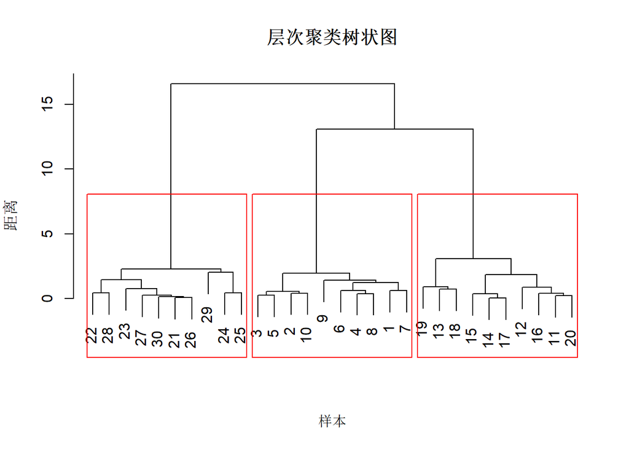

```r
# 层次聚类示例
set.seed(42)

# 生成模拟数据
n_samples <- 30
hclust_data <- data.frame(
  feature1 = c(rnorm(n_samples/3, 2, 0.5),
               rnorm(n_samples/3, 5, 0.5),
               rnorm(n_samples/3, 8, 0.5)),
  feature2 = c(rnorm(n_samples/3, 2, 0.5),
               rnorm(n_samples/3, 5, 0.5),
               rnorm(n_samples/3, 2, 0.5))
)

# 计算距离矩阵
dist_matrix <- dist(hclust_data)

# 执行层次聚类（使用Ward方法）
hclust_result <- hclust(dist_matrix, method = "ward.D2")

# 绘制树状图
plot(hclust_result, main = "层次聚类树状图",
     xlab = "样本", ylab = "距离", sub = "")

# 添加矩形框标记聚类
rect.hclust(hclust_result, k = 3, border = "red")
```

### 树状图解读

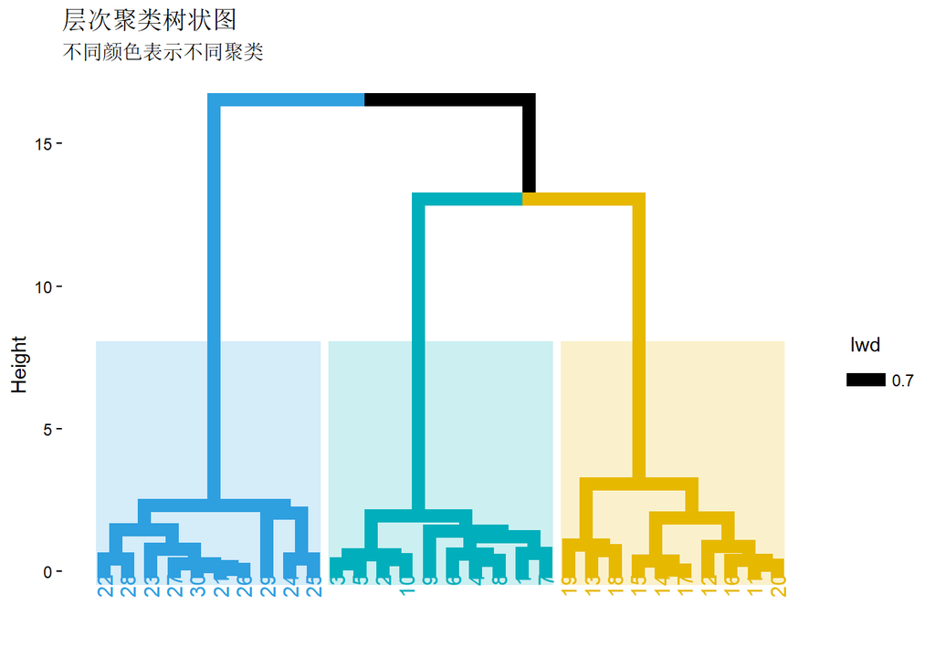

```r
# 使用factoextra包绘制更美观的树状图
factoextra::fviz_dend(hclust_result, k = 3,
                      cex = 0.8,
                      k_colors = c("#2E9FDF", "#00AFBB", "#E7B800"),
                      rect = TRUE,
                      rect_border = c("#2E9FDF", "#00AFBB", "#E7B800"),
                      rect_fill = TRUE,
                      lower_rect = -0.5) +
  ggplot2::labs(
    title = "层次聚类树状图",
    subtitle = "不同颜色表示不同聚类"
  )
```

### 切割树状图获取聚类

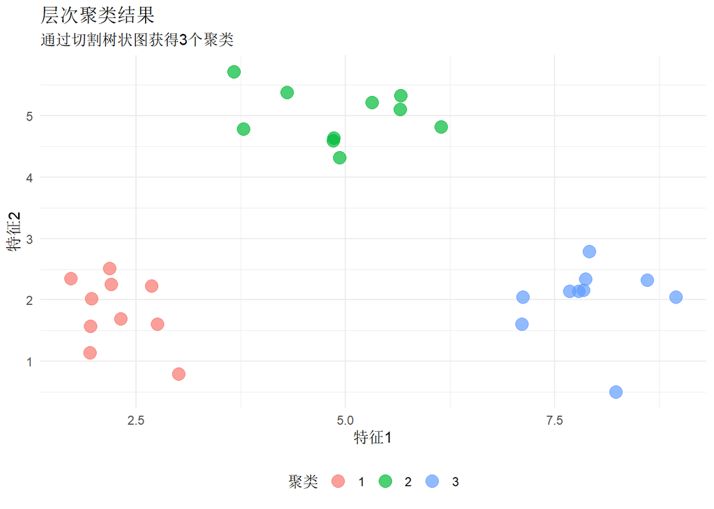

```r
# 切割树状图，获取3个聚类
clusters <- cutree(hclust_result, k = 3)

# 将聚类结果添加到数据框
hclust_data$cluster <- as.factor(clusters)

# 可视化聚类结果
ggplot2::ggplot(hclust_data, ggplot2::aes(x = feature1, y = feature2)) +
  ggplot2::geom_point(ggplot2::aes(color = cluster), size = 4, alpha = 0.7) +
  ggplot2::labs(
    title = "层次聚类结果",
    subtitle = "通过切割树状图获得3个聚类",
    x = "特征1", y = "特征2", color = "聚类"
  ) +
  ggplot2::theme_minimal() +
  ggplot2::theme(legend.position = "bottom")
```

### 意义与使用场景

**核心意义**：层次聚类提供了数据的层次结构视图，便于理解数据的组织方式。

**举例**：疾病分类研究

**为什么这种数据适合用层次聚类？**

疾病分类往往具有层次结构，如疾病大类下分亚类，亚类下再分亚型。层次聚类可以揭示这种自然的层次关系，帮助理解疾病的分类体系。

**研究目的是什么？**

1. 发现疾病的层次分类结构
2. 在不同粒度上理解疾病关系
3. 为临床诊断提供参考框架

**可能得到什么样的结果？**

层次聚类可能揭示疾病从大类到亚类的自然分组，如自身免疫病→系统性→系统性红斑狼疮。

**需要注意什么？**

层次聚类一旦合并就不能撤销，可能导致早期错误传播。计算复杂度较高，不适合大规模数据。

## 9.4 DBSCAN密度聚类

### 基本原理

**DBSCAN（Density-Based Spatial Clustering of Applications with Noise）** 是一种基于密度的聚类算法，能够发现任意形状的簇，并识别噪声点。

**核心概念**：

| 概念 | 定义 |
| --- | --- |
| 核心点 | ε邻域内至少有MinPts个点的点 |
| 边界点 | 不是核心点，但在某核心点的ε邻域内 |
| 噪声点 | 既不是核心点也不是边界点 |

**参数**： - **ε（eps）**：邻域半径 - **MinPts**：形成核心点的最小邻居数

```r
# DBSCAN聚类示例
set.seed(42)

# 生成非球形数据：两个同心圆
n_per_circle <- 100

# 外圆
theta_outer <- runif(n_per_circle, 0, 2 * pi)
outer_circle <- data.frame(
  x = 5 * cos(theta_outer) + rnorm(n_per_circle, 0, 0.2),
  y = 5 * sin(theta_outer) + rnorm(n_per_circle, 0, 2),
  true_cluster = "外圆"
)

# 内圆
theta_inner <- runif(n_per_circle, 0, 2 * pi)
inner_circle <- data.frame(
  x = 2 * cos(theta_inner) + rnorm(n_per_circle, 0, 0.2),
  y = 2 * sin(theta_inner) + rnorm(n_per_circle, 0, 0.2),
  true_cluster = "内圆"
)

# 合并数据
dbscan_data <- rbind(outer_circle, inner_circle)

# 执行DBSCAN聚类
dbscan_result <- dbscan::dbscan(dbscan_data[, c("x", "y")],
                                 eps = 0.5, minPts = 5)

# 查看聚类结果
print("DBSCAN聚类结果：")
```

```
## [1] "DBSCAN聚类结果："
```

```r
print(table(dbscan_result$cluster))
```

```
##
##  0  1  2  3  4
## 88  8 20 60 24
```

```r
# 0表示噪声点
print(paste("噪声点数量:", sum(dbscan_result$cluster == 0)))
```

```
## [1] "噪声点数量: 88"
```